# final_slider slides

#### Rodrigo Morel - Lizeth Contreras - Martín Fernando Ortiz

### Maestría de Geomática - UNLP

## Geoestadística

### Análisis de datos meteorológicos

### Objetivo General

Aplicar de técnicas de geoestadística para el análisis de datos meteorológicos

### Objetivos Específicos

- Hacer un análisis descriptivo de la información del dataset
- Tratar los datos outliers
- Realizar un análisis PCA
- Generar una interpolación para el caso en que tengamos No Datos
- Hacer predicción de datos para un nuevo dataset de estaciones
- Utilizar alguna técnica de Cluster para generar regiones climatológicas

### Software utilizado

Jupyter / Colab - Python

### Dataset utilizado

Dataset de la cátedra de Geoestadística

### Código

https://github.com/martinfernandoortiz/geoestadistica_unlp/tree/main/final

## Corrección del Dataset

- Corrección de Coordenadas

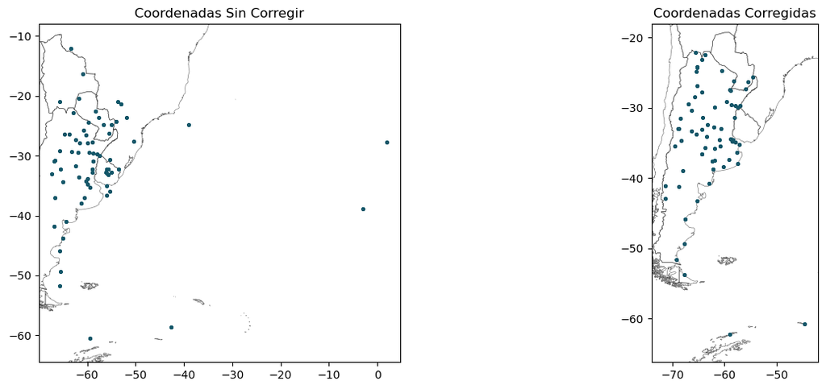

```python
plot_geo_dataframes(pais, df_coords, df_original)
```

## Corrección del Dataset

- Se transformaron los campos con valores "S/D" a np_nan

```python
# @title
df = df.applymap(lambda x: np.NaN if x == "S/D" else x)
```

## Corrección del Dataset

- Se modificaron los tipos de datos a numeric/float

## Estadística descriptiva del Dataset

```python
# @title
df.iloc[:, np.r_[7:15]].describe()
```

|  | Temperatura_(C) | Temperatura_maxima_(C) | Temperatura_minima_(C) | Humedad_relativa_(%) | Velocidad_del_Viento_(km/h) | Nubosidad_total_(octavos) | Precipitacion_(mm) | Frecuencia_dias_Precipitacion_>0.1_mm |
| --- | --- | --- | --- | --- | --- | --- | --- | --- |
| count | 838.000000 | 840.000000 | 818.000000 | 812.000000 | 708.000000 | 826.000000 | 807.000000 | 807.000000 |
| mean | 15.871838 | 22.411667 | 10.225428 | 68.044581 | 12.456497 | 3.817191 | 69.334944 | 6.756877 |
| std | 6.996565 | 7.443672 | 6.775667 | 10.828241 | 5.390830 | 0.764862 | 52.093688 | 2.763202 |
| min | -11.600000 | -7.300000 | -16.800000 | 30.100000 | 3.000000 | 1.400000 | 0.000000 | 0.000000 |
| 25% | 11.200000 | 18.000000 | 5.525000 | 62.175000 | 8.700000 | 3.400000 | 23.400000 | 4.750000 |
| 50% | 16.300000 | 23.100000 | 10.700000 | 70.200000 | 11.300000 | 3.700000 | 59.000000 | 7.100000 |
| 75% | 21.700000 | 28.300000 | 15.475000 | 76.325000 | 14.800000 | 4.100000 | 108.600000 | 8.700000 |
| max | 27.900000 | 35.100000 | 22.300000 | 88.100000 | 30.800000 | 7.500000 | 237.000000 | 16.300000 |

### Distribución de los datos

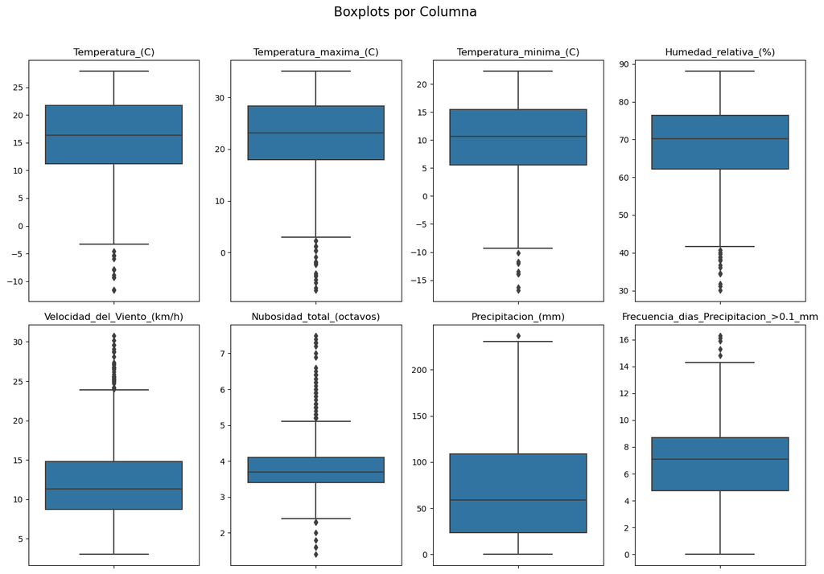

```python
plot_boxplots(df)
```

### Porcentaje de datos por fuera de los bigotes

Q1 − 1.5 ∗ RI y Q3 + 1.5 ∗ RI.

```python
outliers_df
```

|  | Temperatura_(C) | Temperatura_maxima_(C) | Temperatura_minima_(C) | Humedad_relativa_(%) | Velocidad_del_Viento_(km/h) | Nubosidad_total_(octavos) | Precipitacion_(mm) | Frecuencia_dias_Precipitacion_>0.1_mm |
| --- | --- | --- | --- | --- | --- | --- | --- | --- |
| No es Outlier | 0.986905 | 0.978571 | 0.990476 | 0.983333 | 0.958333 | 0.933333 | 0.99881 | 0.994048 |
| Es Outlier | 0.013095 | 0.021429 | 0.009524 | 0.016667 | 0.041667 | 0.066667 | 0.00119 | 0.005952 |
| lower_lim | -4.550000 | 2.550000 | -9.400000 | 40.950000 | -0.450000 | 2.350000 | -104.40000 | -1.175000 |
| upper_lim | 37.450000 | 43.750000 | 30.400000 | 97.550000 | 23.950000 | 5.150000 | 236.40000 | 14.625000 |

## Localización de Outliers y No datos

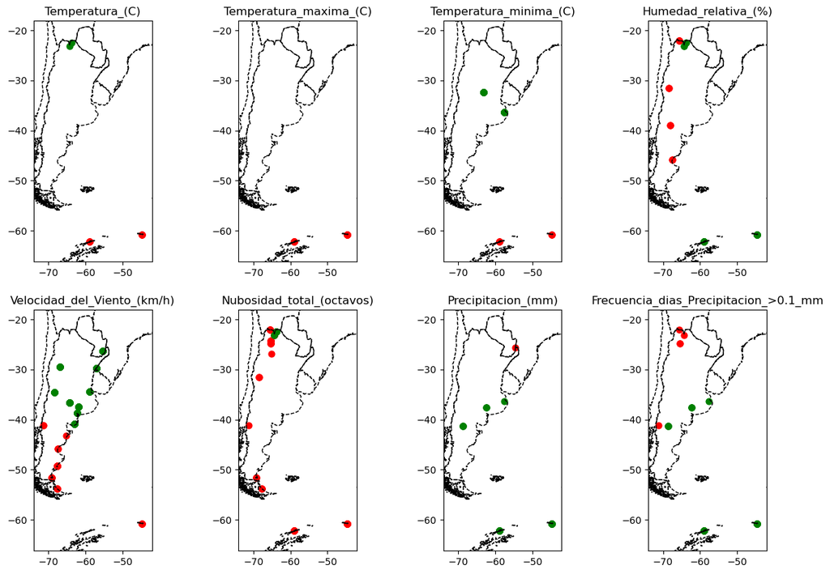

```python
plot_outliers_and_nan(df)
```

## Tratamiento de Outliers

- se le asigno el valor de la mediana a los outliers

# Análisis de Componentes Principales (PCA)

```python
pca_1()
```

[output not shown]

```python
print("Correlación entre las variables originales seleccionadas y las PC:")
print(selected_variables_correlation)
```

```
Correlación entre las variables originales seleccionadas y las PC:
                             PC1       PC2       PC3       PC4       PC5  \
Temperatura_maxima_(C) -0.508337  0.112016  0.013822  0.199641  0.118833
Precipitacion_(mm)     -0.368804 -0.401210  0.262702 -0.313822 -0.731669

                             PC6       PC7
Temperatura_maxima_(C)  0.727252 -0.382076
Precipitacion_(mm)      0.009592  0.009276
```

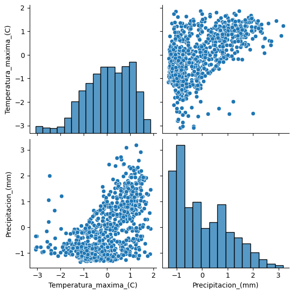

```python
sns.pairplot(gdf, vars=selected_variables, height=3)
plt.show()
```

## Interpolación IDW

Vamos a reemplazar los valores NO DATO por el resultado de la interpolación IDW. La interpolación se va a realizar tambien en base a las medianas anuales de cada estación

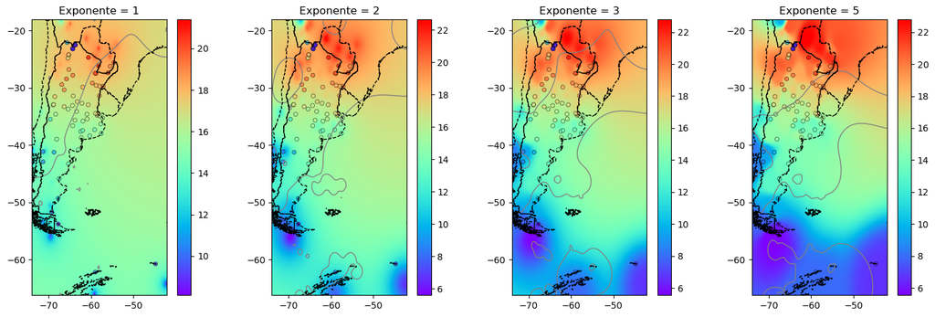

```python
plot_interpolacion(x, y, z, xi, yi, exponentes, country_boundaries, Isocontornos)
```

Utilizando el método IDW vemos que al aumentar el exponente aumenta el contraste en la representaciòn de la grilla. Es decir, con valores más altos de exponente la distribución de los valores tiene mayor varianza

## Interpolación KNN

Con el dataset ya interpolado, vamos a hacer un modelo KNN para estimar valores de nuevas estaciones en donde no tenemos información.

- Se separó el dataset en 20% 80%
- Se fueron haciendo varias pruebas de la cantidad de vecinos para ver cuales dan mejores resultados
- Finalmente el valor elegido fue de k= 1

```python
print_regression_metrics(mae, mse, rmse, reg_score)
```

```
MAE: 0.9228354978354982
MSE: 1.514790518824611
RMSE: 1.2307682636567336
R2 Score: 0.9042589565696563
```

El valor de r2 0.90 da cuenta de que el modelo tiene buen rendimiento

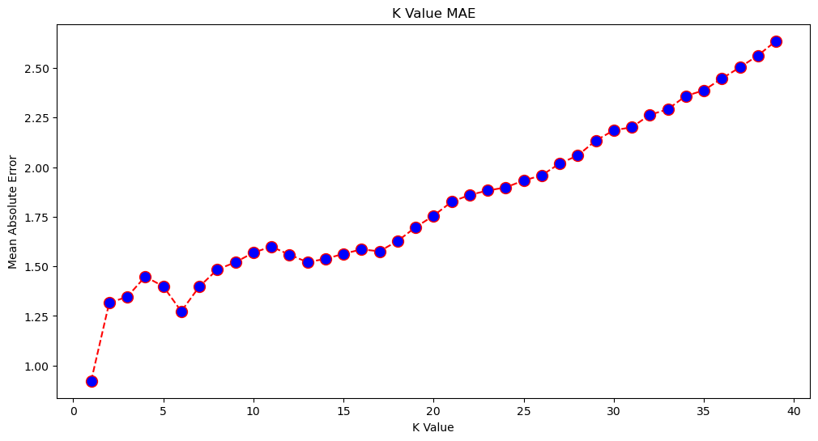

```python
plot_error_vs_k(k_range, error)
```

En los gráficos se puede observar que el valor óptimo es 1

### Inteporlación sobre nuevas estaciones

A continuación se muestra la aplicación del modelo para nuevas estaciones en donde no hay dato

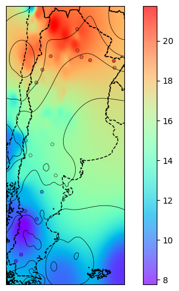

```python
inter()
```

## Cluster Jerárquico

Vamos a realizar análisis de cluster para ver si podemos agrupar las estaciones en "zonas climatológicas" Las variables utilizadas son: Temperatura, Velocidad del Viento y Nubosidad Total

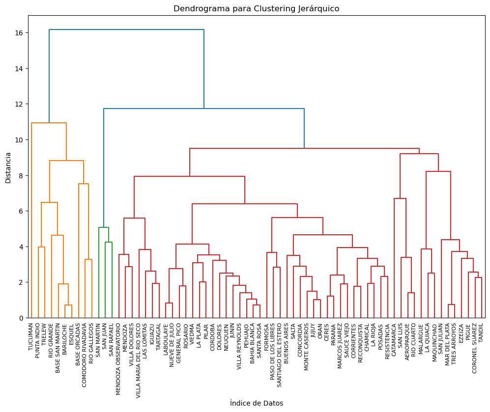

```python
plot_dendrogram(linkage_matrix, normalized_data.index)
```

```
Method: complete-linkage
```

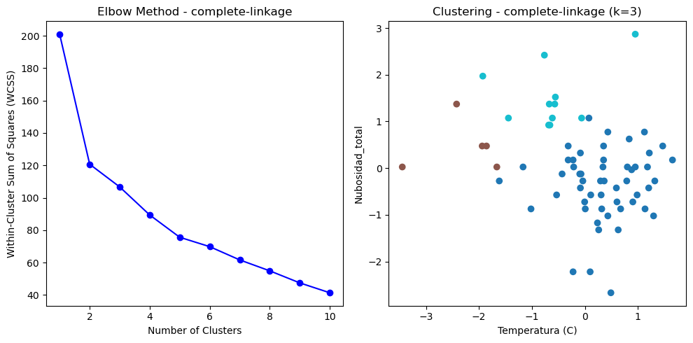

```python
plot_cluster_analysis(normalized_data)
```

```
Method: complete-linkage
```

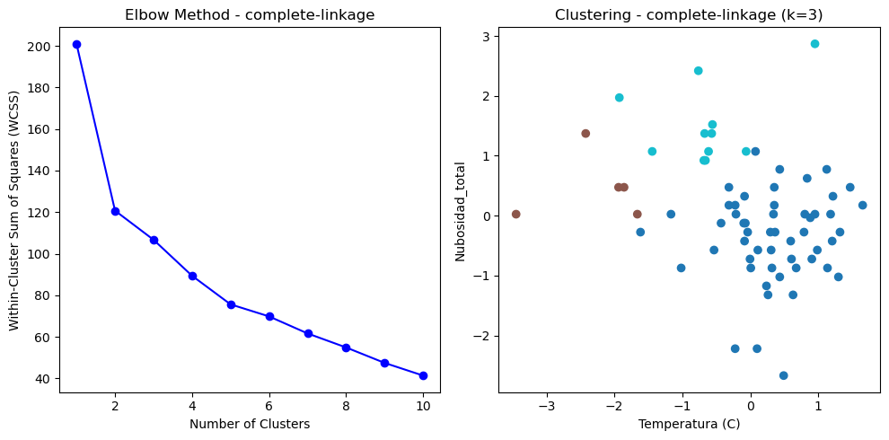

```python
plot_cluster_analysis(normalized_data)
```

```
Method: average-linkage
```

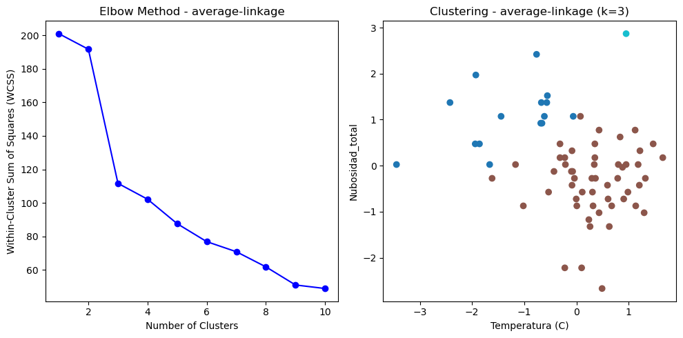

```python
plot_cluster_analysis(normalized_data)
```

```python
metricas()
```

```
Number of clusters: 3
Transformation: Standardize (Z)
Method: Average-linkage
Distance function: Euclidean
```

```python
print("\nThe total sum of squares:", sst)
print("Within-cluster sum of squares:")
for i, wcss in enumerate(wcss_values):
    print(f"C{i + 1} : {wcss}")
print("\nThe total within-cluster sum of squares:", sum(wcss_values))
print("The between-cluster sum of squares:", bcss)
print("The ratio of between to total sum of squares:", bcss / sst)
```

```
The total sum of squares: 201.0
Within-cluster sum of squares:
C1 : 27.26102975359794
C2 : 84.3821608667548
C3 : 0.0

The total within-cluster sum of squares: 111.64319062035274
The between-cluster sum of squares: 89.35680937964726
The ratio of between to total sum of squares: 0.4445612406947625
```

[figure not shown]

```python
plot_scatter_with_clusters(variables_clustering)
```

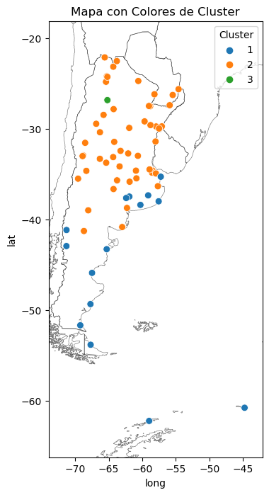

```python
plot_map_with_clusters(gdf_jerarquico, pais, mapeo)
```

## K-Means Cluster

```python
metrica_k()
```

```
Cluster centers:
   Temperatura_(C)  Velocidad_del_Viento_(km/h)  Nubosidad_total_(octavos)
0        15.226768                    12.200773                   3.678788
1         8.913542                    17.741667                   4.006250
2        19.422839                     9.081416                   3.630259

Within-cluster sum of squares:
   Within cluster S.S.
0           366.264354
1            68.964957
2           232.267640
```

```python
print("\nThe total within-cluster sum of squares:", total_within_cluster_ss)
print("The between-cluster sum of squares:", between_cluster_ss)
print("The ratio of between to total sum of squares:", ratio_between_to_total_ss)
```

```
The total within-cluster sum of squares: 667.4969510339395
The between-cluster sum of squares: 6623.4103262623885
The ratio of between to total sum of squares: 0.9084480263365157
```

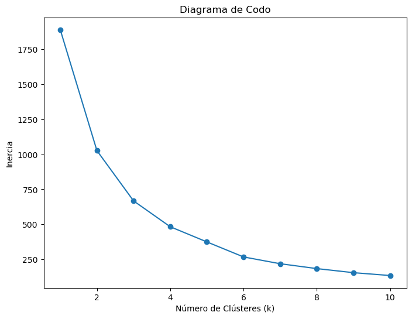

```python
codo()
```

[figure not shown]

```python
scater()
```

[figure not shown]

```python
pmapa_clusters(merged_df1,pais,mapeo)
```